# Interpreting Visualizations

## Plots and Tables, Error Bars and Confidence Intervals, Year-to-Year Changes, Y-Axis Breaks

## Plots and Tables

**Line** or **bar plots** are used to display the weighted (adjusted) percentage of the BRC population who have a particular characteristic in common:

# Spirituality

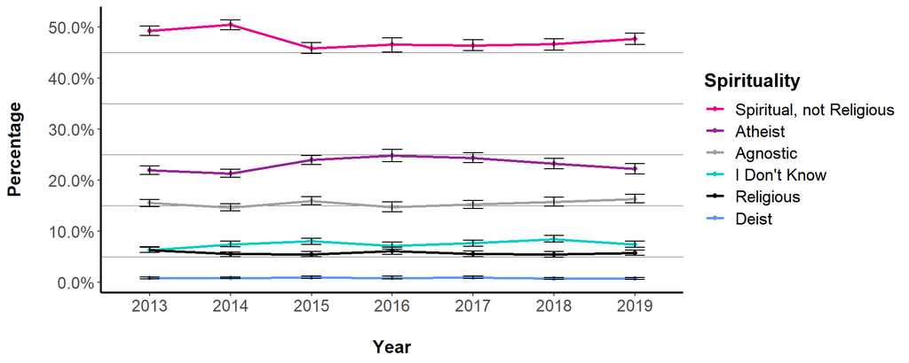

Error bars indicate the upper and lower bounds of the 95% confidence intervals.

In most cases, the actual percentage values are not displayed within the plot. They can be found in the accompanying **data table**, along with the margin of error (labeled “MoE +/-%”):

|  | 2013 Percent | 2013 MoE +/- % |  | 2014 Percent | 2014 MoE +/- % |  | 2015 Percent | 2015 MoE +/- % |  | 2016 Percent | 2016 MoE +/- % |  | 2017 Percent | 2017 MoE +/- % |  | 2018 Percent | 2018 MoE +/- % |  | 2019 Percent | 2019 MoE +/- % |
| --- | --- | --- | --- | --- | --- | --- | --- | --- | --- | --- | --- | --- | --- | --- | --- | --- | --- | --- | --- | --- |
| Spiritual, not Religious | 49.2 | 1.0 |  | 50.4 | 1.0 |  | 45.8 | 1.0 |  | 46.5 | 1.4 |  | 46.4 | 1.2 |  | 46.6 | 1.2 |  | 47.7 | 1.2 |
| Atheist | 21.9 | 0.8 |  | 21.3 | 0.8 |  | 23.9 | 1.0 |  | 24.8 | 1.2 |  | 24.3 | 1.0 |  | 23.2 | 1.0 |  | 22.2 | 1.0 |
| Agnostic | 15.5 | 0.8 |  | 14.6 | 0.8 |  | 15.9 | 0.8 |  | 14.7 | 1.0 |  | 15.2 | 0.8 |  | 15.7 | 0.8 |  | 16.3 | 0.8 |
| I Don’t Know | 6.3 | 0.6 |  | 7.4 | 0.6 |  | 8.0 | 0.6 |  | 7.1 | 0.8 |  | 7.6 | 0.6 |  | 8.4 | 0.6 |  | 7.4 | 0.6 |
| Religious | 6.3 | 0.4 |  | 5.5 | 0.4 |  | 5.4 | 0.6 |  | 6.1 | 0.6 |  | 5.5 | 0.6 |  | 5.4 | 0.6 |  | 5.7 | 0.6 |
| Deist | 0.8 | 0.2 |  | 0.8 | 0.2 |  | 0.9 | 0.2 |  | 0.8 | 0.2 |  | 0.9 | 0.2 |  | 0.7 | 0.2 |  | 0.7 | 0.2 |

All numbers are rounded to the nearest 0.1%, so in some cases the total percentage values do not add up to exactly 100.0%.

## Error Bars and Confidence Intervals

Error bars are the black I-shaped markers that overlay each data point on a line or bar plot:

[figure not shown]

While each data point shows a weighted percentage, there is always some degree of uncertainty when estimating the characteristics of a population based on a sample of that population - in this case, the entire BRC population in a given year from the BRC citizens who provided data to BRC Census.

The 95% confidence intervals indicated by these error bars help to show the degree of that uncertainty: there is a 95% probability that the upper and lower bounds of the I-shape contain the true value. They are a visual representation of the margin of error (shown in the “MoE +/- %” column in the data table) which measures the amount of “error” or uncertainty in the results of a survey conducted via random sample. On rare occasions due to rounding, the margin of error may vary from the 95% confidence intervals by around 0.1%.

# Burning Man Virgin

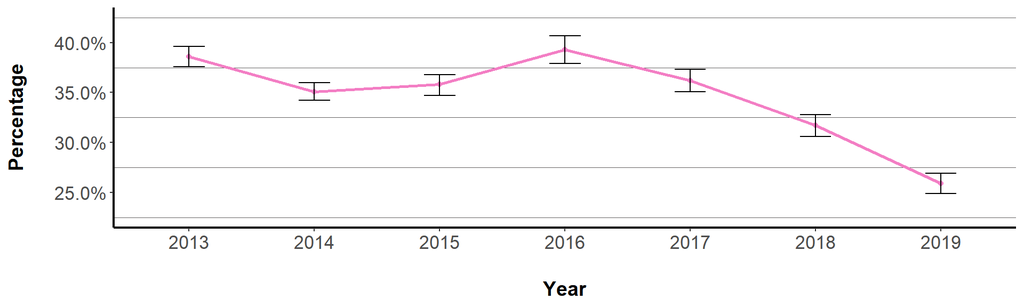

Error bars indicate the upper and lower bounds of the 95% confidence intervals.

|  | 2013 Percent | 2013 MoE +/- % |  | 2014 Percent | 2014 MoE +/- % |  | 2015 Percent | 2015 MoE +/- % |  | 2016 Percent | 2016 MoE +/- % |  | 2017 Percent | 2017 MoE +/- % |  | 2018 Percent | 2018 MoE +/- % |  | 2019 Percent | 2019 MoE +/- % |
| --- | --- | --- | --- | --- | --- | --- | --- | --- | --- | --- | --- | --- | --- | --- | --- | --- | --- | --- | --- | --- |
| Virgin | 38.6 | 1.0 |  | 35.1 | 1.0 |  | 35.8 | 1.0 |  | 39.3 | 1.4 |  | 36.2 | 1.2 |  | 31.7 | 1.2 |  | 25.9 | 1.0 |

In the plot and table above, 31.7% of the 2018 BRC population were estimated to be Burning Man virgins according to the weighted survey results. It can be said with 95% confidence that the true virgin proportion of the BRC population is contained within the range between 30.6% and 32.8% (95% confidence intervals); roughly 31.7% plus or minus 1.2% (margin of error; note the slight discrepancy due to rounding error).

## Year-to-Year Changes

When reviewing changes in a population over time, it is extremely important to remember that some reported changes will be due to sampling methodology (using weighted Census data to report on the BRC population) or measurement error, rather than being indicative of a consistently occurring change in the population.

As a general rule, smaller differences from one year to another are more likely to be due to chance, while larger differences are more likely to be indicative of genuine changes in the BRC population. Additional caution should be taken in situations with larger confidence intervals, as they indicate less certainty as to the exact population proportion.

For example, in the plot below:

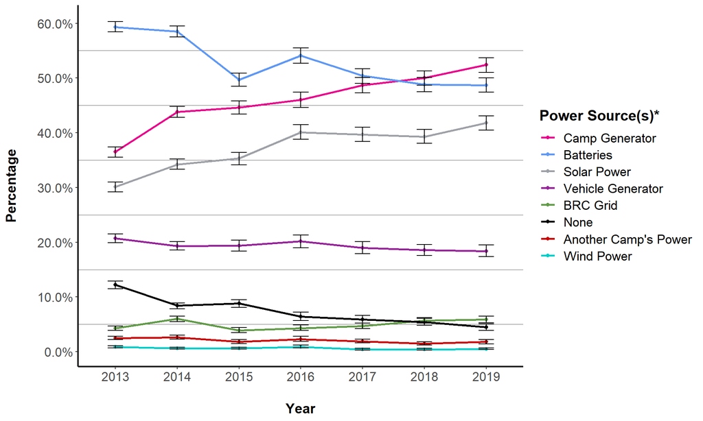

The **teal line** (bottom) for wind power use is relatively flat, with relatively small confidence intervals. The proportion of Burners using wind power does not seem to have changed much from 2013-2017.

The **purple line** (middle) for vehicle generator use shows larger changes from 2013-2017, but the confidence intervals are also larger. In some cases where the data points look relatively far apart from one year to the next, the confidence intervals for those years overlap. It is difficult to know if these changes are due to random chance or to other, more significant population trends.

The **blue line** (top) for battery use shows large changes from 2013 to 2015, even taking into account the height of the confidence intervals. It is more likely, though not certain, that these changes are not due to random factors.

## Y-Axis Breaks

# Current Gender

Roughly 56-59% of BRC's population has self-identified as male.

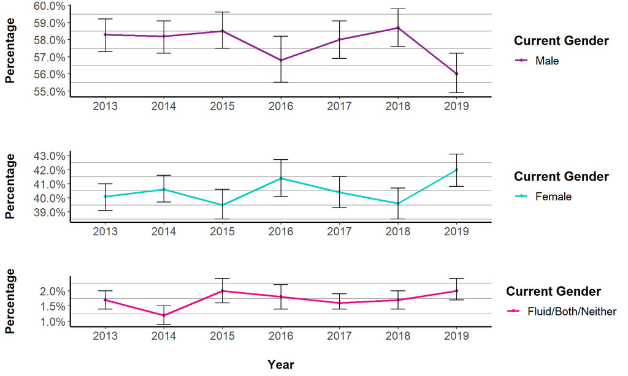

Error bars indicate the upper and lower bounds of the 95% confidence intervals.

Roughly 39-42% of BRC's population has self-identified as female.

Roughly 1-2% of BRC's population has self-identified as fluid, both, or neither.

Displaying all of these results on a continuous percentage scale would be difficult. Without a very tall image, slanted lines would appear to be nearly horizontal and the lines in similar proportion ranges (male and female, in this case) would overlap each other to such a degree as to become indistinguishable from one another. To improve plot readability in these situations, multiple plots are stacked with the irrelevant ranges (the parts of the y-axis not included in any response range) excluded entirely.

**Next:** Sociodemographic Characteristics: BRC Population, Past Burning Man Experience, Age, Ethnicity, Education, Income, and Creative Self-Identities